# R Notebook

**Principles of Data Visualization and Introduction to ggplot2**

I have provided you with data about the 5,000 fastest growing companies in the US, as compiled by Inc. magazine. lets read this in:

```r
inc <- read.csv("https://raw.githubusercontent.com/charleyferrari/CUNY_DATA_608/master/module1/Data/inc5000_data.csv", header= TRUE)
```

And lets preview this data:

```r
head(inc)
```

```
##   Rank                         Name Growth_Rate   Revenue
## 1    1                         Fuhu      421.48 1.179e+08
## 2    2        FederalConference.com      248.31 4.960e+07
## 3    3                The HCI Group      245.45 2.550e+07
## 4    4                      Bridger      233.08 1.900e+09
## 5    5                       DataXu      213.37 8.700e+07
## 6    6 MileStone Community Builders      179.38 4.570e+07
##                       Industry Employees         City State
## 1 Consumer Products & Services       104   El Segundo    CA
## 2          Government Services        51     Dumfries    VA
## 3                       Health       132 Jacksonville    FL
## 4                       Energy        50      Addison    TX
## 5      Advertising & Marketing       220       Boston    MA
## 6                  Real Estate        63       Austin    TX
```

```r
summary(inc)
```

```
##       Rank                          Name       Growth_Rate
##  Min.   :   1   (Add)ventures         :   1   Min.   :  0.340
##  1st Qu.:1252   @Properties           :   1   1st Qu.:  0.770
##  Median :2502   1-Stop Translation USA:   1   Median :  1.420
##  Mean   :2502   110 Consulting        :   1   Mean   :  4.612
##  3rd Qu.:3751   11thStreetCoffee.com  :   1   3rd Qu.:  3.290
##  Max.   :5000   123 Exteriors         :   1   Max.   :421.480
##                 (Other)               :4995
##     Revenue                                  Industry      Employees
##  Min.   :2.000e+06   IT Services                 : 733   Min.   :    1.0
##  1st Qu.:5.100e+06   Business Products & Services: 482   1st Qu.:   25.0
##  Median :1.090e+07   Advertising & Marketing     : 471   Median :   53.0
##  Mean   :4.822e+07   Health                      : 355   Mean   :  232.7
##  3rd Qu.:2.860e+07   Software                    : 342   3rd Qu.:  132.0
##  Max.   :1.010e+10   Financial Services          : 260   Max.   :66803.0
##                      (Other)                     :2358   NA's   :12
##             City          State
##  New York     : 160   CA     : 701
##  Chicago      :  90   TX     : 387
##  Austin       :  88   NY     : 311
##  Houston      :  76   VA     : 283
##  San Francisco:  75   FL     : 282
##  Atlanta      :  74   IL     : 273
##  (Other)      :4438   (Other):2764
```

Think a bit on what these summaries mean. Use the space below to add some more relevant non-visual exploratory information you think helps you understand this data:

```r
print(colnames(inc))
```

```
## [1] "Rank"        "Name"        "Growth_Rate" "Revenue"     "Industry"
## [6] "Employees"   "City"        "State"
```

What exactly is the data about? The column names help with that.

```r
sapply(inc, class)
```

```
##        Rank        Name Growth_Rate     Revenue    Industry   Employees
##   "integer"    "factor"   "numeric"   "numeric"    "factor"   "integer"
##        City       State
##    "factor"    "factor"
```

So does identifying the data in each column without sifting through it.

```r
revenue_by_industry <- data.frame(t(sapply(levels(inc$Industry), function(x) summary(inc[inc$Industry==x,]$Revenue))))
revenue_by_industry
```

```
##                                 Min. X1st.Qu.   Median      Mean  X3rd.Qu.
## Advertising & Marketing      2000000  4100000  7900000  16528662  14950000
## Business Products & Services 2000000  4700000  9850000  54705187  25400000
## Computer Hardware            3800000 12950000 22350000 270129545  48775000
## Construction                 2100000  7000000 14000000  70450802  34300000
## Consumer Products & Services 2000000  4000000  9400000  73676847  20800000
## Education                    2000000  3850000  6800000  13726506  13250000
## Energy                       2100000  8600000 29400000 126344954 108100000
## Engineering                  2100000  5950000 12100000  34222973  27075000
## Environmental Services       2100000  5150000 12500000  51741176  35000000
## Financial Services           2000000  6000000 15550000  50580385  47125000
## Food & Beverage              2000000  7400000 18600000  98559542  55950000
## Government Services          2000000  6325000 11450000  29748020  24150000
## Health                       2000000  5550000 11400000  50319437  33650000
## Human Resources              2000000  5500000 11450000  47173980  37225000
## Insurance                    2700000  6900000 12650000  46758000  30425000
## IT Services                  2000000  4700000 10000000  28214598  24100000
## Logistics & Transportation   2300000  7100000 20800000  95745161  48700000
## Manufacturing                2100000  5500000 11900000  49546875  35300000
## Media                        2100000  4500000  7600000  32266667  18500000
## Real Estate                  2100000  6100000 12800000  30892708  33975000
## Retail                       2000000  4300000  8200000  50529064  23900000
## Security                     2000000  5800000 12300000  52230137  28700000
## Software                     2000000  4900000  8700000  23802924  22275000
## Telecommunications           2100000  8200000 16600000  56855814  31700000
## Travel & Hospitality         2200000  4375000  8600000  47283871  17400000
##                                   Max.
## Advertising & Marketing      3.568e+08
## Business Products & Services 2.400e+09
## Computer Hardware            1.010e+10
## Construction                 4.700e+09
## Consumer Products & Services 4.600e+09
## Education                    1.457e+08
## Energy                       1.900e+09
## Engineering                  6.887e+08
## Environmental Services       1.400e+09
## Financial Services           9.591e+08
## Food & Beverage              4.500e+09
## Government Services          1.400e+09
## Health                       2.700e+09
## Human Resources              5.377e+08
## Insurance                    5.350e+08
## IT Services                  3.800e+09
## Logistics & Transportation   1.900e+09
## Manufacturing                1.700e+09
## Media                        4.415e+08
## Real Estate                  5.170e+08
## Retail                       2.800e+09
## Security                     7.181e+08
## Software                     4.875e+08
## Telecommunications           8.462e+08
## Travel & Hospitality         5.066e+08
```

Each industry produces revenue, and having it all collected in a single place lets us pick out which industries are the most profitable.

```r
employees_by_industry <- data.frame(t(sapply(levels(inc$Industry), function(x) summary(na.omit(inc[inc$Industry==x,]$Employees)))))
employees_by_industry
```

```
##                              Min. X1st.Qu. Median       Mean X3rd.Qu.
## Advertising & Marketing         2    22.00   37.0   84.35456    74.00
## Business Products & Services    4    24.00   49.0  244.49375   127.00
## Computer Hardware               6    27.00   45.5  220.77273    85.25
## Construction                    3    24.00   47.0  155.60963   113.50
## Consumer Products & Services    1    17.00   34.0  223.96059    79.00
## Education                       1    22.00   44.0   92.59036   100.00
## Energy                          2    25.00   70.0  242.54128   245.00
## Engineering                    11    35.50   64.0  276.14865   146.75
## Environmental Services          4    30.00   67.0  199.11765   122.00
## Financial Services              5    28.00   70.0  183.43462   190.50
## Food & Beverage                 3    24.00   65.0  510.93798   235.00
## Government Services             6    34.25   71.0  129.62871   142.75
## Health                          2    32.25   71.0  232.85311   200.00
## Human Resources                 4    26.00   71.5 1158.06122   271.00
## Insurance                       7    32.75   53.0  146.78000    94.00
## IT Services                     2    27.00   57.0  140.42077   130.00
## Logistics & Transportation      1    18.00   50.0  259.70130   178.00
## Manufacturing                   1    24.00   49.0  172.32157   124.50
## Media                           2    19.25   34.0  176.51852    89.00
## Real Estate                     2    20.00   49.0  198.87368   126.50
## Retail                          2    13.00   31.0  182.60099    83.50
## Security                        7    33.00   77.0  562.45205   226.00
## Software                        1    32.00   69.0  150.32845   153.00
## Telecommunications              6    25.50   65.0  242.85039   136.50
## Travel & Hospitality            3    15.00   38.0  371.53226   205.25
##                               Max.
## Advertising & Marketing       5637
## Business Products & Services 32000
## Computer Hardware             6800
## Construction                  6549
## Consumer Products & Services 13200
## Education                      850
## Energy                        2501
## Engineering                  10000
## Environmental Services        5347
## Financial Services            1829
## Food & Beverage               7681
## Government Services           1352
## Health                        4390
## Human Resources              66803
## Insurance                     2877
## IT Services                   7000
## Logistics & Transportation   10800
## Manufacturing                 8500
## Media                         3300
## Real Estate                   2391
## Retail                        5821
## Security                     20000
## Software                      3000
## Telecommunications           10000
## Travel & Hospitality          4878
```

Knowing how many employees there are for each industry’s businesses also is informative.

```r
employee_val_by_industry <- revenue_by_industry/employees_by_industry
employee_val_by_industry[order(employee_val_by_industry$Mean, decreasing=TRUE),]
```

```
##                                   Min. X1st.Qu.   Median       Mean
## Computer Hardware             633333.3 479629.6 491208.8 1223563.93
## Energy                       1050000.0 344000.0 420000.0  520921.44
## Construction                  700000.0 291666.7 297872.3  452740.64
## Logistics & Transportation   2300000.0 394444.4 416000.0  368674.17
## Consumer Products & Services 2000000.0 235294.1 276470.6  328972.37
## Insurance                     385714.3 210687.0 238679.2  318558.39
## Manufacturing                2100000.0 229166.7 242857.1  287525.67
## Retail                       1000000.0 330769.2 264516.1  276718.46
## Financial Services            400000.0 214285.7 222142.9  275740.67
## Environmental Services        525000.0 171666.7 186567.2  259852.29
## Telecommunications            350000.0 321568.6 255384.6  234118.68
## Government Services           333333.3 184671.5 161267.6  229486.35
## Business Products & Services  500000.0 195833.3 201020.4  223748.81
## Health                       1000000.0 172093.0 160563.4  216099.49
## IT Services                  1000000.0 174074.1 175438.6  200928.95
## Advertising & Marketing      1000000.0 186363.6 213513.5  195942.71
## Food & Beverage               666666.7 308333.3 286153.8  192899.23
## Media                        1050000.0 233766.2 223529.4  182794.80
## Software                     2000000.0 153125.0 126087.0  158339.45
## Real Estate                  1050000.0 305000.0 261224.5  155338.34
## Education                    2000000.0 175000.0 154545.5  148249.84
## Travel & Hospitality          733333.3 291666.7 226315.8  127267.20
## Engineering                   190909.1 167605.6 189062.5  123929.53
## Security                      285714.3 175757.6 159740.3   92861.49
## Human Resources               500000.0 211538.5 160139.9   40735.31
##                               X3rd.Qu.       Max.
## Computer Hardware            572140.76 1485294.12
## Energy                       441224.49  759696.12
## Construction                 302202.64  717666.82
## Logistics & Transportation   273595.51  175925.93
## Consumer Products & Services 263291.14  348484.85
## Insurance                    323670.21  185957.59
## Manufacturing                283534.14  200000.00
## Retail                       286227.54  481017.01
## Financial Services           247375.33  524384.91
## Environmental Services       286885.25  261829.06
## Telecommunications           232234.43   84620.00
## Government Services          169176.88 1035502.96
## Business Products & Services 200000.00   75000.00
## Health                       168250.00  615034.17
## IT Services                  185384.62  542857.14
## Advertising & Marketing      202027.03   63296.08
## Food & Beverage              238085.11  585861.22
## Media                        207865.17  133787.88
## Software                     145588.24  162500.00
## Real Estate                  268577.08  216227.52
## Education                    132500.00  171411.76
## Travel & Hospitality          84774.67  103854.04
## Engineering                  184497.44   68870.00
## Security                     126991.15   35905.00
## Human Resources              137361.62    8049.04
```

On average, the industries who have the most revenue per employee are Computer Hardware, Energy, Construction, Logistics & Transportation, and Consumer Products & Services.

```r
employee_val_by_industry[order(employee_val_by_industry$`Min.`, decreasing=TRUE),]
```

```
##                                   Min. X1st.Qu.   Median       Mean
## Logistics & Transportation   2300000.0 394444.4 416000.0  368674.17
## Manufacturing                2100000.0 229166.7 242857.1  287525.67
## Consumer Products & Services 2000000.0 235294.1 276470.6  328972.37
## Education                    2000000.0 175000.0 154545.5  148249.84
## Software                     2000000.0 153125.0 126087.0  158339.45
## Energy                       1050000.0 344000.0 420000.0  520921.44
## Media                        1050000.0 233766.2 223529.4  182794.80
## Real Estate                  1050000.0 305000.0 261224.5  155338.34
## Advertising & Marketing      1000000.0 186363.6 213513.5  195942.71
## Health                       1000000.0 172093.0 160563.4  216099.49
## IT Services                  1000000.0 174074.1 175438.6  200928.95
## Retail                       1000000.0 330769.2 264516.1  276718.46
## Travel & Hospitality          733333.3 291666.7 226315.8  127267.20
## Construction                  700000.0 291666.7 297872.3  452740.64
## Food & Beverage               666666.7 308333.3 286153.8  192899.23
## Computer Hardware             633333.3 479629.6 491208.8 1223563.93
## Environmental Services        525000.0 171666.7 186567.2  259852.29
## Business Products & Services  500000.0 195833.3 201020.4  223748.81
## Human Resources               500000.0 211538.5 160139.9   40735.31
## Financial Services            400000.0 214285.7 222142.9  275740.67
## Insurance                     385714.3 210687.0 238679.2  318558.39
## Telecommunications            350000.0 321568.6 255384.6  234118.68
## Government Services           333333.3 184671.5 161267.6  229486.35
## Security                      285714.3 175757.6 159740.3   92861.49
## Engineering                   190909.1 167605.6 189062.5  123929.53
##                               X3rd.Qu.       Max.
## Logistics & Transportation   273595.51  175925.93
## Manufacturing                283534.14  200000.00
## Consumer Products & Services 263291.14  348484.85
## Education                    132500.00  171411.76
## Software                     145588.24  162500.00
## Energy                       441224.49  759696.12
## Media                        207865.17  133787.88
## Real Estate                  268577.08  216227.52
## Advertising & Marketing      202027.03   63296.08
## Health                       168250.00  615034.17
## IT Services                  185384.62  542857.14
## Retail                       286227.54  481017.01
## Travel & Hospitality          84774.67  103854.04
## Construction                 302202.64  717666.82
## Food & Beverage              238085.11  585861.22
## Computer Hardware            572140.76 1485294.12
## Environmental Services       286885.25  261829.06
## Business Products & Services 200000.00   75000.00
## Human Resources              137361.62    8049.04
## Financial Services           247375.33  524384.91
## Insurance                    323670.21  185957.59
## Telecommunications           232234.43   84620.00
## Government Services          169176.88 1035502.96
## Security                     126991.15   35905.00
## Engineering                  184497.44   68870.00
```

The industries with the greatest minimum revenue per employee are Logistics & Transportiation, Manufacturing, Consumer Products & Services, Education, and Software.

## Question 1

Create a graph that shows the distribution of companies in the dataset by State (ie how many are in each state). There are a lot of States, so consider which axis you should use. This visualization is ultimately going to be consumed on a ‘portrait’ oriented screen (ie taller than wide), which should further guide your layout choices.

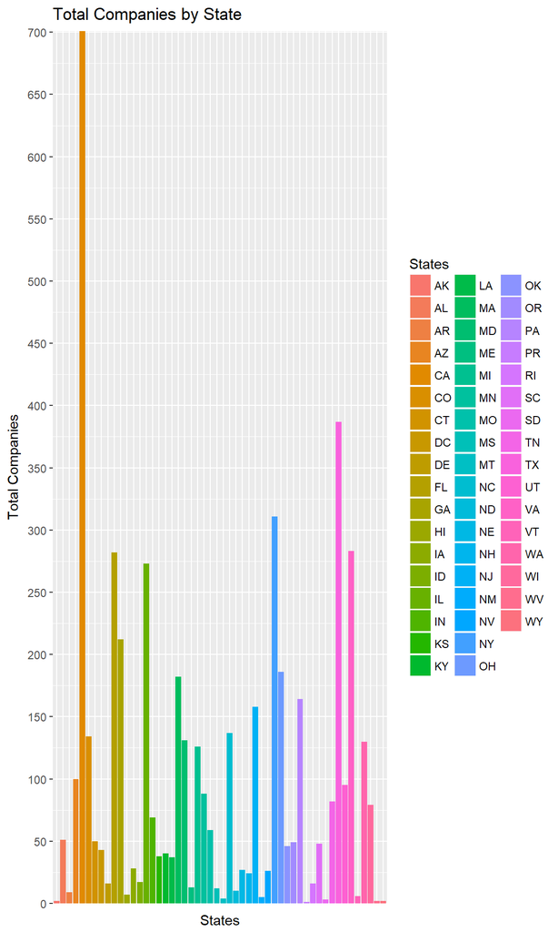

```r
library(ggplot2)

# barplot(summary(inc$State), las=2, cex.names=0.5, col="pink", main="Number of Companies by State") # Not bad, but base R... ggplot...

ggplot() +
  geom_histogram(aes(inc$State, fill=inc$State), stat="count") +
  labs(x = "States", y="Total Companies", title="Total Companies by State", fill="States") +
  scale_color_gradient(low="blue", high="red") +
  scale_y_continuous(breaks=seq(0, 800, 50), expand = c(0, 0)) +
  theme(axis.text.x = element_blank(), axis.ticks.x = element_blank())
```

## Quesiton 2

Lets dig in on the state with the 3rd most companies in the data set. Imagine you work for the state and are interested in how many people are employed by companies in different industries. Create a plot that shows the average and/or median employment by industry for companies in this state (only use cases with full data, use R’s `complete.cases()` function.) In addition to this, your graph should show how variable the ranges are, and you should deal with outliers.

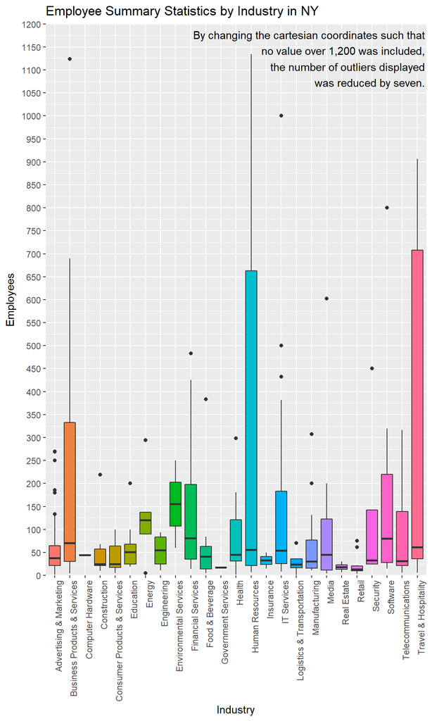

```r
state_3rd_most <- names(sort(table(inc$State), decreasing=TRUE)[3])
ggplot(data=inc[complete.cases(inc) & inc$State==state_3rd_most,]) +
  geom_boxplot(aes(x=Industry, y=Employees, fill=Industry)) +
  coord_cartesian(ylim=c(0,1200)) +
  theme(axis.text.x = element_text(angle = 90, hjust = 1)) +
  labs(title=paste("Employee Summary Statistics by Industry in", state_3rd_most)) +
  annotate("text", label="By changing the cartesian coordinates such that\nno value over 1,200 was included,\nthe number of outliers displayed\nwas reduced by seven.", x=25.5, y=1125, hjust = 1) +
  scale_y_continuous(breaks=seq(0, 1200, 50), expand = c(0, 0)) +
  guides(fill=FALSE)
```

## Question 3

Now imagine you work for an investor and want to see which industries generate the most revenue per employee. Create a chart that makes this information clear. Once again, the distribution per industry should be shown.

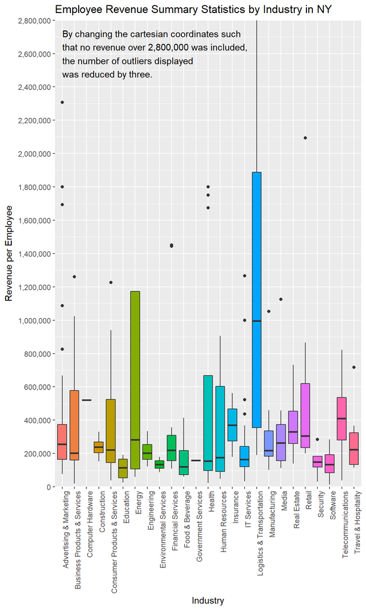

```r
ggplot(data=inc[complete.cases(inc) & inc$State==state_3rd_most,]) +
  geom_boxplot(aes(x=Industry, y=Revenue/Employees, fill=Industry)) +
  coord_cartesian(ylim=c(0,2800000)) +
  theme(axis.text.x = element_text(angle = 90, hjust = 1)) +
  labs(title=paste("Employee Revenue Summary Statistics by Industry in", state_3rd_most), y = "Revenue per Employee") +
  annotate("text", label="By changing the cartesian coordinates such\nthat no revenue over 2,800,000 was included,\nthe number of outliers displayed\nwas reduced by three.", x=1, y=2600000, hjust = 0) +
  scale_y_continuous(breaks=seq(0, 2800000, 200000), labels=scales::comma, expand=c(0,0)) +
  guides(fill=FALSE)
```